# The subtee plot function

2022-03-22

In this vignette we showcase the various plots can be made with the package.

## Analyzing the data

We first start producing the treatment effect estimates for all subgroups, using the `unadj`, `modav` and `bagged` functions.

```r
library(ggplot2)
library(subtee)
################################################################################
# We use the dataset from Rosenkranz (2016) https://onlinelibrary.wiley.com/doi/abs/10.1002/bimj.201500147
# to illustrate the methods proposed in this work.
# The data comes from a clinical trial of an prostate cancer
# treatment
# Data is loaded from  Royston, Patrick, and Willi Sauerbrei.
# Multivariable model-building: a pragmatic approach to
# regression anaylsis based on fractional polynomials for
# modelling continuous variables. Vol. 777. John Wiley & Sons, 2008.
# https://www.imbi.uni-freiburg.de/Royston-Sauerbrei-book
prca = get_prca_data()
## first create candidate subgroups
cand.groups <- subtee::subbuild(prca, dupl.rm = TRUE,
                               BM == 1, PF == 1, HX == 1,
                               STAGE == 4, AGE > 65, WT > 100)
fitdat <- cbind(prca, cand.groups)
subgr.names = names(cand.groups)
prog = as.formula(paste(" ~ ", paste0("`", names(cand.groups),"`", collapse = " + ")))

### Unadjusted estimates
res_unadj = unadj(resp = "SURVTIME", trt = "RX", subgr = subgr.names,
                  data = fitdat, covars = prog,
                  event = "CENS", fitfunc = "coxph")
### ModelAveraging estimates
res_modav = modav(resp = "SURVTIME", trt = "RX", subgr = subgr.names,
                  data = fitdat, covars = prog,
                  event = "CENS", fitfunc = "coxph")
### Bagged estimates
set.seed(321231) # set seed for reproducible results in the bootstrap samples
res_bagged = bagged(resp = "SURVTIME", trt = "RX", subgr = subgr.names,
                    data = fitdat, covars = prog,
                    event = "CENS", fitfunc = "coxph",
                    select.by = "BIC", B = 200) #B = 2000)
```

## Plotting treatment effect estimates in subgroups

The objects resulting from calling `unadj`, `modav` and `bagged` are `subtee` objects that contain the results in a format that can be used to produce plots. For example, the following produces a forest plot showing treatment effect estimates for the subgroups and their complements:

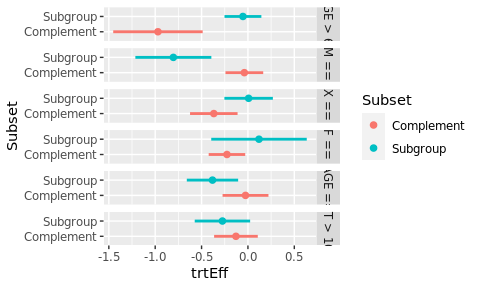

```r
ggplot(aes(y = Subset, x = trtEff, xmin = LB, xmax = UB, colour = Subset),
       data = res_unadj$trtEff) +
  geom_point(size = 2) +
  geom_errorbarh(size = 1, show.legend = FALSE, height = 0) +
  facet_grid(Group ~ .)
```

### Using the generic `plot` function provided in the package

The default option for the generic plot function in the package for `subtee` objects shows the treatment effect in subgroups along with their confidence intervals.

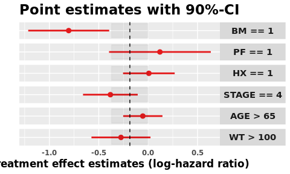

```r
plot(res_unadj)
```

Note that only the treatment effect estimates in subgroups are displayed. Setting the option `show.compl = TRUE` displays the treatment effect estimates in both subgroups and complements.

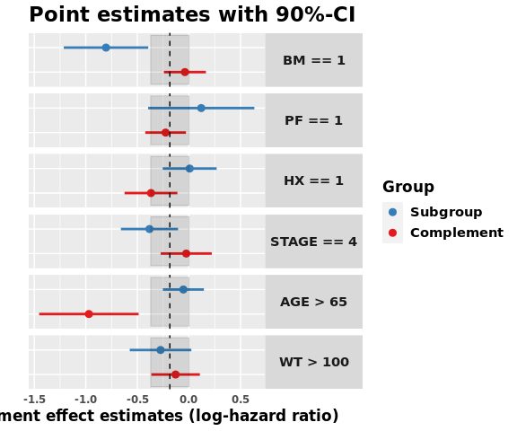

```r
plot(res_unadj, show.compl = TRUE)
```

When using the `plot` function to `subtee` objects with unadjusted or model averaging estimates, the same layout is used. However, when the a `subtee` object generated with the `bagged` funciton is provided. it will only show the selected subgroup.

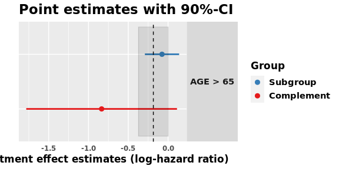

```r
plot(res_bagged, show.compl = TRUE)
```

### Comparing different estimation techniques

When more than one object is provided, the plot shows the comparison between different estimation techniques.

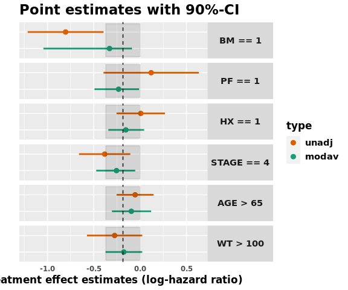

```r
plot(res_unadj, res_modav, palette = "Dark2")
```

In this case it is again possible to set `show.compl = TRUE`.

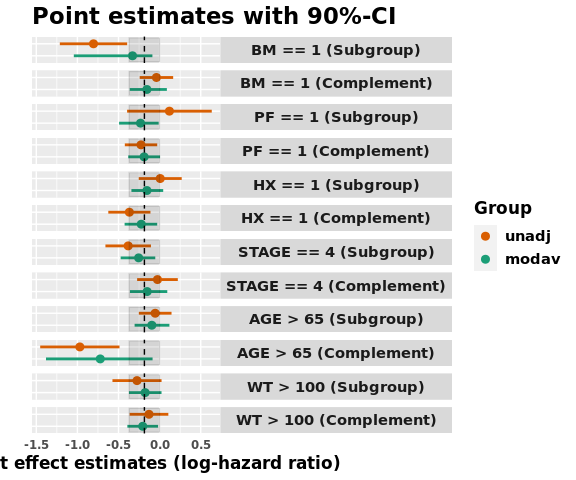

```r
plot(res_unadj, res_modav, show.compl = TRUE)
```

And if bagged estimates are provided, it will only show the selected subgroup.

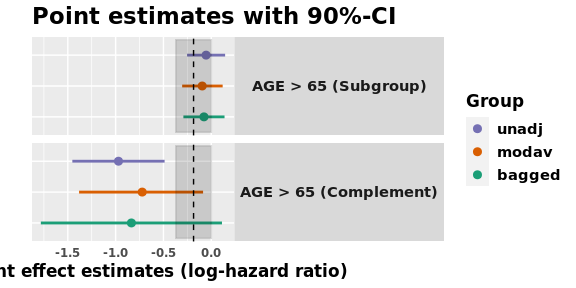

```r
plot(res_unadj, res_modav, res_bagged, show.compl = TRUE)
```

## Plotting treatment effect difference between subgroup and complement

The `plot` function has also the option to show the treatment effect difference between subgroup and complement setting `type = "trtEffDiff"`.

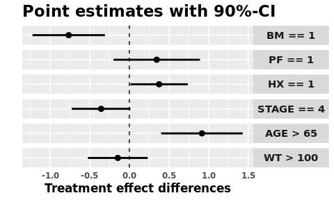

```r
plot(res_unadj, type = "trtEffDiff")
```

And it is also possible to compare

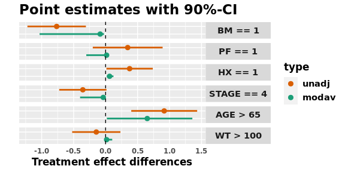

```r
plot(res_unadj, res_modav, type = "trtEffDiff")
```

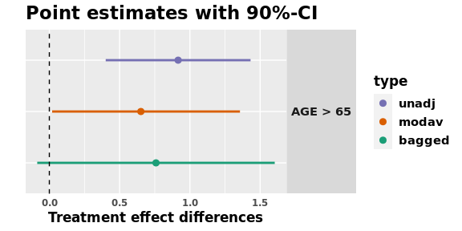

```r
plot(res_unadj, res_modav, res_bagged, type = "trtEffDiff")
```